# DS 4635 Homework 1

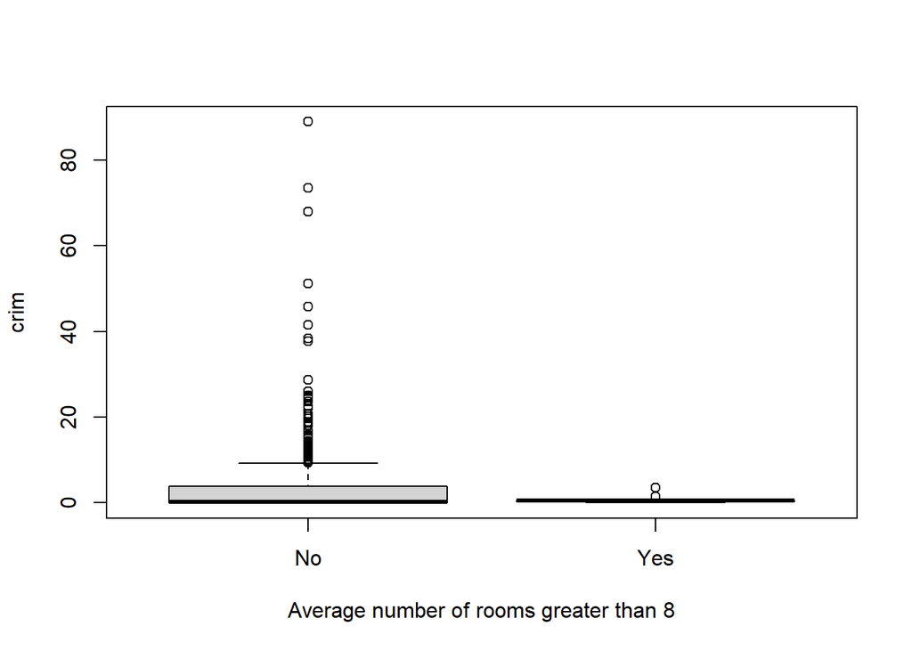

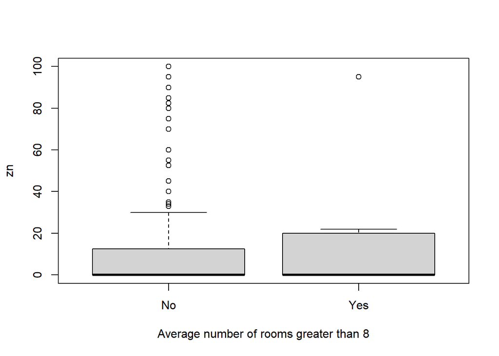

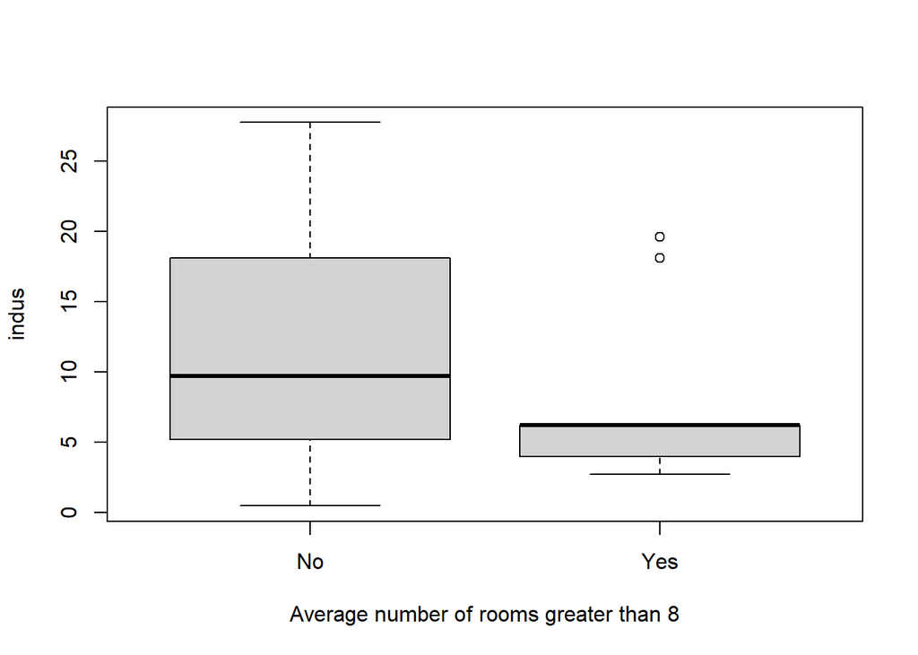

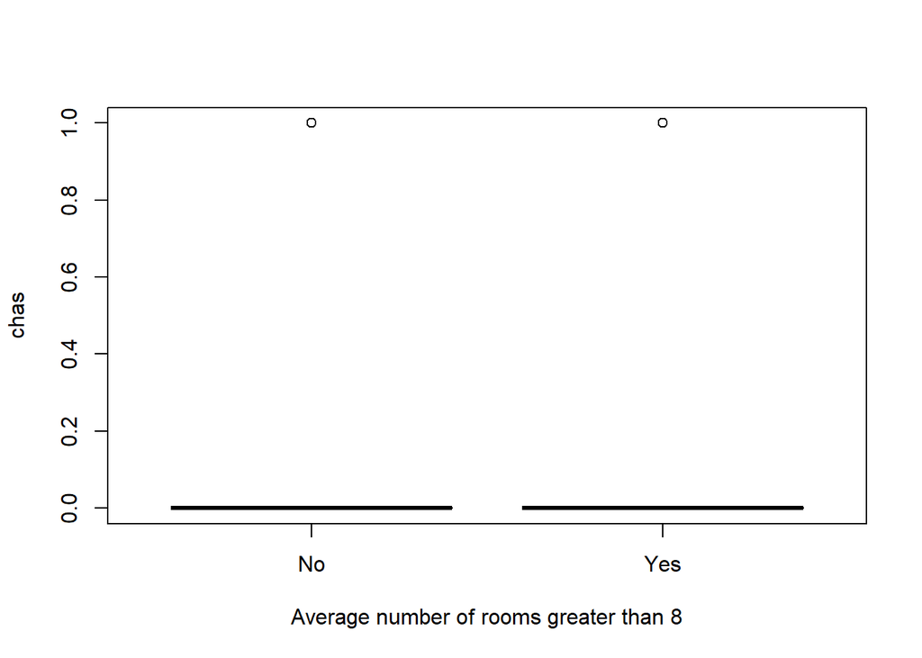

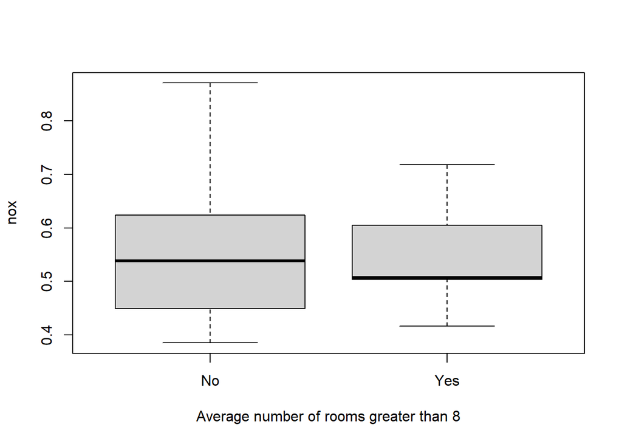

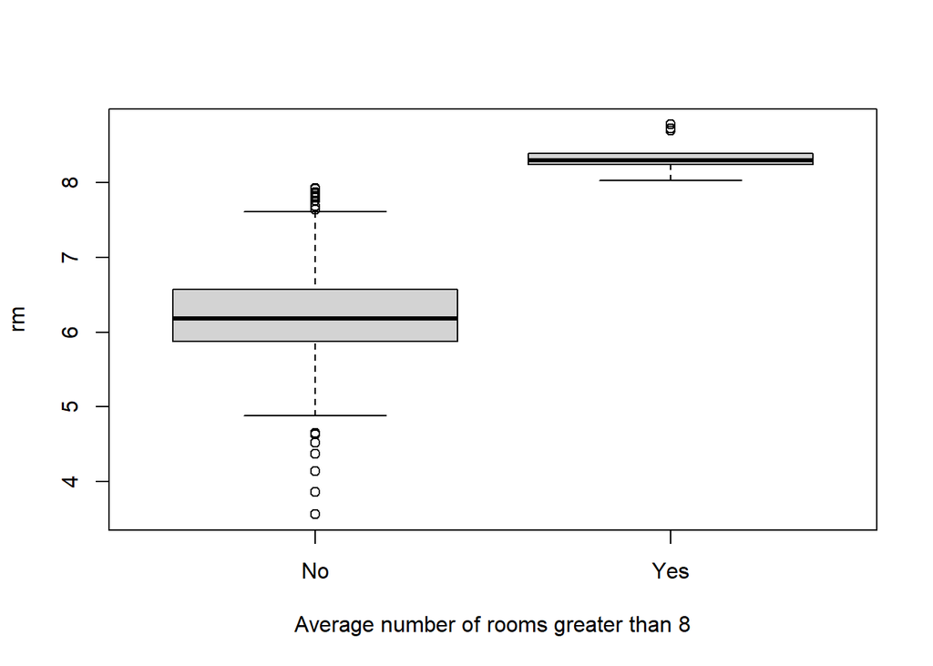

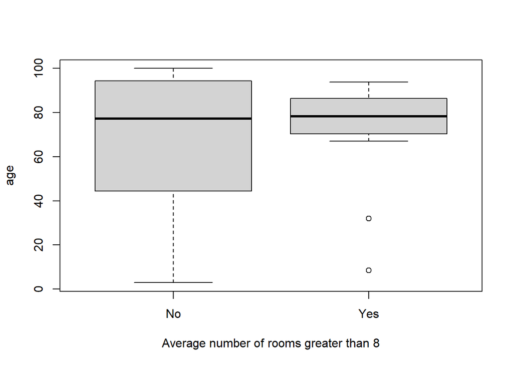

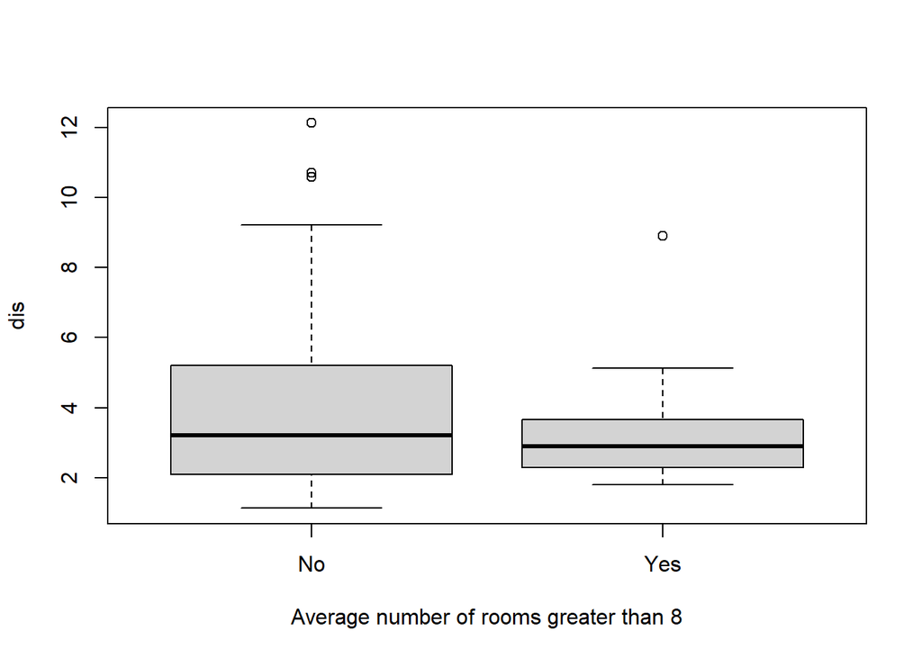

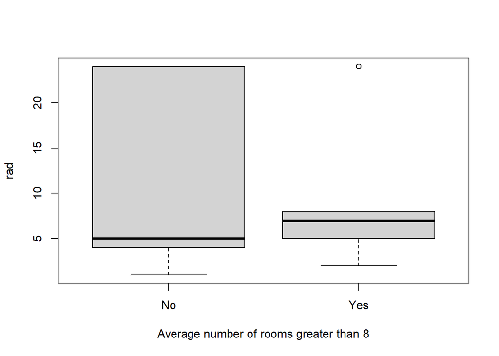

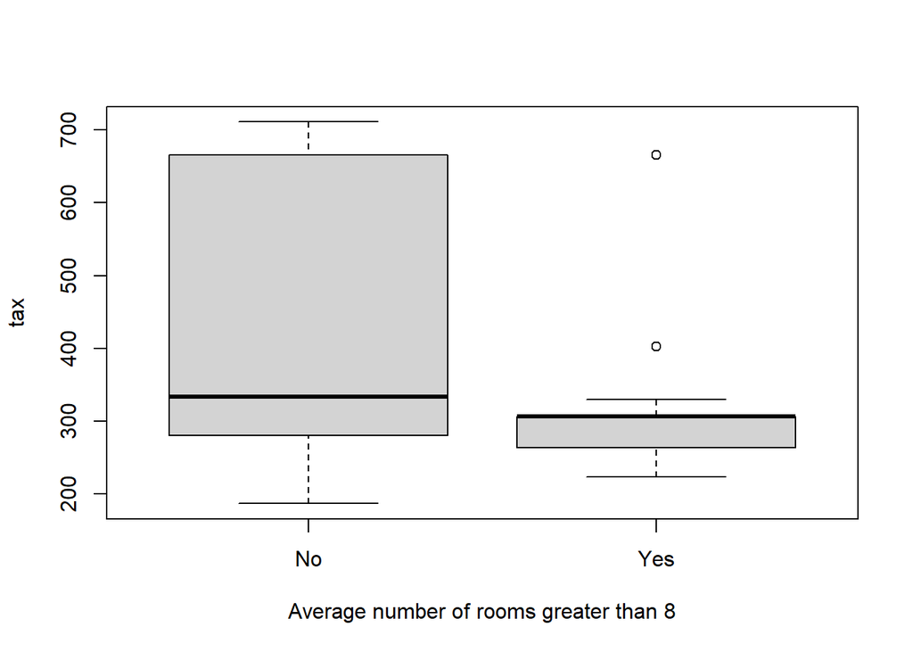

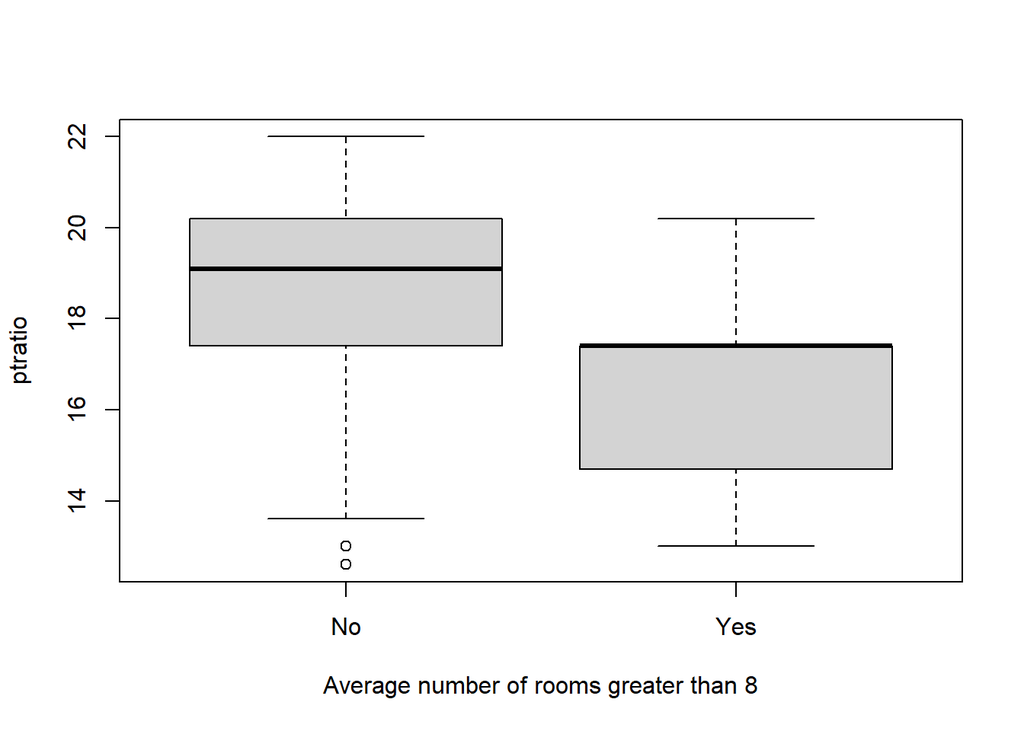

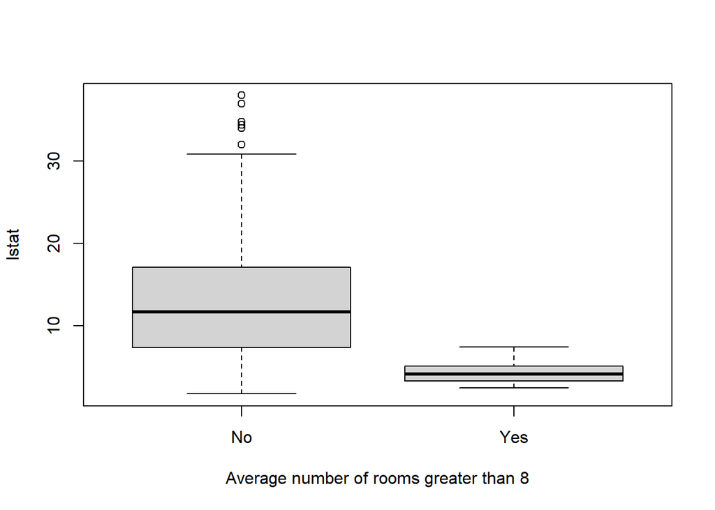

[1 more figures not shown]

```r
#summary(eight)

rm8 = rep("No", nrow(boston))
rm8[boston[,"rm"] > 8] = "Yes"
rm8 = as.factor(rm8)
boston = data.frame(boston, rm8)

for (n in names(Boston)){
  plot(boston$rm8,boston[,n], xlab = "Average number of rooms greater than 8", ylab = n)
}
```

**There are 64 with an average of more than 7 and 13 with an average of more than 8. We can see how this subset compares to the complete dataset using the above boxplots. For example, census tracts in this subset are less industrialized, have a lower pupil-teacher ratio, have a lower population of lower status individuals, and have higher median home values.**